# Data Mining-1

### Homework -1.3 (25 Points)

1. Apply both k-means and DBSCAN for the randomly generated cluster data above.
2. Plot the results for both algorithms by highlighting clusters in different colors.
3. Interpret your results. If you observe a difference in the output of two algorithms, write up a paragraph contining your examination as why one algorithm performed better than the other.

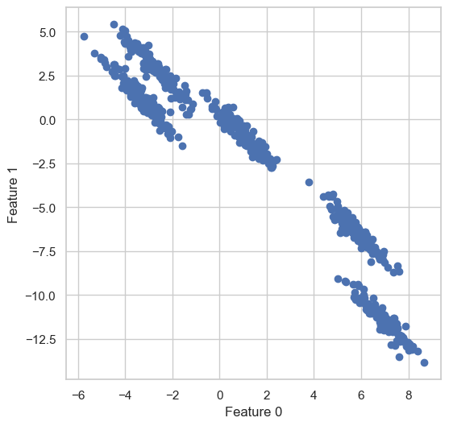

```python
import numpy as np
import matplotlib.pyplot as plt
from sklearn.datasets import make_blobs
import seaborn as sns

# We do this to ignore several specific Pandas warnings
import warnings
warnings.filterwarnings("ignore")

# generate some random cluster data
X, y = make_blobs(random_state=170, n_samples=600, centers = 5)
rng = np.random.RandomState(74)
# transform the data to be stretched
transformation = rng.normal(size=(2, 2))
X = np.dot(X, transformation)
# plot
plt.figure(figsize=(6,6))
plt.scatter(X[:, 0], X[:, 1])
plt.xlabel("Feature 0")
plt.ylabel("Feature 1")
plt.show()
```

## Ans:

1. Let us set up the Kmeans object
2. Let us run an elbow function, fitting various sizes on the dataset to find the elbow wrt the lowest inertia.

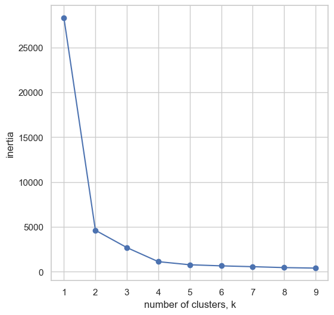

```python
from sklearn.cluster import KMeans
ks = range(1, 10)
inertia = []

for k in ks:
    # Create a KMeans instance with k clusters: model
    model = KMeans(n_clusters=k)

    # Fit model to samples
    model.fit(X)

    # Append the inertia to the list of inertias
    inertia.append(model.inertia_)

# Plot ks vs inertias
plt.figure(figsize=(6,6))
plt.plot(ks, inertia, '-o')
plt.xlabel('number of clusters, k')
plt.ylabel('inertia')
plt.xticks(ks)
plt.show()
```

Looking at the Elbow Curve, we can see that the Points 2,3,4,5 are parts of the elbow. We can then fit the model with these parameters and compare the results.

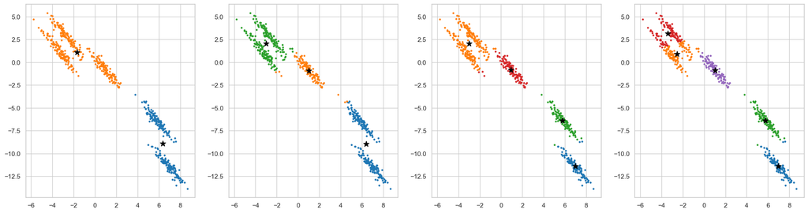

```python
runs = [2,3,4,5]
def run_kmeans(n):
    clusterer = KMeans(n_clusters=n)
    # Fitting the input data
    clusterer = clusterer.fit(X)
    # Getting the cluster labels
    predicted = clusterer.predict(X)
    # Centroid values
    centers = clusterer.cluster_centers_
    return{"centroids":centers,"labels":predicted}
colors = ['#1f77b4', '#ff7f0e', '#2ca02c', '#d62728', '#9467bd', '#8c564b', '#e377c2', '#7f7f7f', '#bcbd22', '#17becf']
fig, axs = plt.subplots(1,len(runs),figsize=(24,6))

for i in range(len(runs)):
    run_values = run_kmeans(runs[i])

    for k in range(runs[i]):
        points = np.array([X[j] for j in range(len(X)) if run_values["labels"][j] == k])
        axs[i].scatter(points[:, 0], points[:, 1], s=5, c=colors[k])
    axs[i].scatter(run_values["centroids"][:,0],run_values["centroids"][:,1], marker='*', s=100, c='#050505')
```

1. Looking at the above graphs, we can clearly see that kmeans is not able to clearly cluster with 5 clusters.
2. A further decision for the subsequent clusters can only be made by trying to infer the reason as to those clusters. Understanding the features and their interactions, might lead to better outcomes.

## DBScan Method

1. Let us plot the nearest neighbours to calculate the optimal epsilon value.

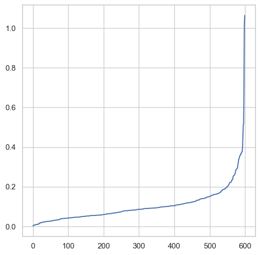

```python
from sklearn.neighbors import NearestNeighbors
neigh = NearestNeighbors(n_neighbors=2)
nbrs = neigh.fit(X)
distances, indices = nbrs.kneighbors(X)
distances = np.sort(distances, axis=0)
distances = distances[:,1]
plt.figure(figsize=(6,6))
plt.plot(distances)
```

2. Looking at the above graph, it looks like the optimal epsilon value is 0.41
3. For choosing the appropriate min_samples value, we can refer to [Ester et al., 1996](https://www.aaai.org/Papers/KDD/1996/KDD96-037.pdf), which indicates that for two-dimensional data we should use a value of 4.

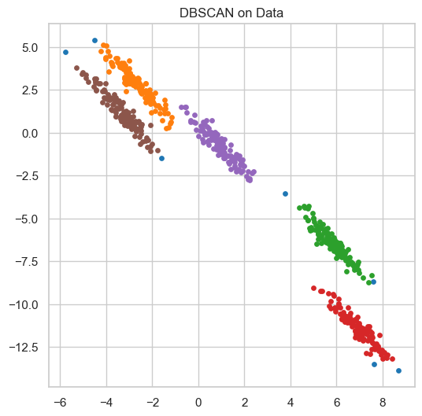

```python
db = DBSCAN(eps=0.41, min_samples=4)
db.fit(X)
sns.set_style("whitegrid")
labels = db.labels_
core_samples = np.zeros_like(labels, dtype = bool)
core_samples[db.core_sample_indices_] = True
unique_labels = np.unique(labels)
colors = ['#1f77b4', '#ff7f0e', '#2ca02c', '#d62728', '#9467bd', '#8c564b']
fig, ax = plt.subplots(figsize=(6, 6))
for (label, color) in zip(unique_labels, colors):
    class_member_mask = (labels == label)
    xy = X[class_member_mask & core_samples]
    ax.scatter(xy[:,0],xy[:,1], label=labels, c = color,s=15)

    xy2 = X[class_member_mask & ~core_samples]
    ax.scatter(xy2[:,0],xy2[:,1], label=labels, c = color,s=15)
plt.title("DBSCAN on Data")
```

### Comparision:

#### Comparing the Kmeans and the DBSCAN methods, we can see the following

1. The KMeans Algorithm is able to cover all the points in the cluster.
2. We can choose how many clusters we need with k-means. This is very usefully in hierarchical data, where hierarchies can be expressed in closeness of individual clusters.
3. The DBSCAN algorithm is expceptionally suited to identifying true clusters, and outlier data.

### Result:

1. Unfortunately without any idea about what the data is, we can not make any suggestions for what the correct choice is, but by looking at the graphs, DBSCAN is probably the best choice, as while we cannot control the number of clusters like k-means, by changing the epsilon and min_samples, we are able to account for that while getting accurate results, that will also be able to accommodate newer observations.